# Informe

## Número de horas de entrenamiento y su relación con el rendimiento académico

## **Introducción**

La relación entre el número de horas de entrenamiento y el rendimiento académico ha sido objeto de investigación en los campos de la educación y la psicología durante décadas. En la actualidad, existe un creciente interés en comprender cómo la cantidad de tiempo que los estudiantes dedican al estudio y a la práctica de habilidades influye en su desempeño en las evaluaciones académicas.

El objetivo principal de este proyecto es investigar cómo el número de horas de entrenamiento y estudio impacta en el rendimiento académico de los estudiantes. Para lograr esto, se utilizarán técnicas de análisis estadístico para examinar los datos recopilados y determinar si existe una correlación significativa entre estas variables. El propósito último de esta investigación es proporcionar una comprensión más profunda de cómo estas variables están relacionadas, con el fin de brindar información valiosa a los educadores y estudiantes sobre cómo mejorar el rendimiento académico a través de un enfoque más efectivo en el tiempo de estudio y entrenamiento.

El análisis estadístico permitirá determinar si existe una correlación positiva, negativa o nula entre estas variables. Además, se explorarán otros factores que podrían influir en el rendimiento académico, como el nivel de motivación y la calidad del tiempo dedicado al estudio.

Los hallazgos de este estudio pueden tener importantes implicaciones para la práctica educativa. Si se encuentra una correlación significativa entre el número de horas de entrenamiento y estudio y el rendimiento académico, esto podría sugerir la importancia de fomentar hábitos de estudio adecuados y asignar tiempo suficiente para el entrenamiento y la práctica de habilidades. Por otro lado, si no se encuentra una correlación significativa, esto podría indicar que la calidad del estudio y la atención prestada a las tareas académicas son factores más influyentes.

### Relevancia

Este estudio es relevante en el campo de la estadística porque su objetivo es analizar y evaluar la relación entre dos variables: el número de horas de entrenamiento y el rendimiento académico. Al analizar estas variables, se puede determinar si existe una correlación significativa entre ellas y, de ser así, se puede utilizar esta información para desarrollar modelos estadísticos que permitan predecir el rendimiento académico de un estudiante en función de las horas de entrenamiento que haya realizado.

En resumen, la relevancia de este estudio en estadística radica en su capacidad para evaluar la relación entre dos variables importantes y proporcionar información valiosa para la toma de decisiones informadas en el campo de la educación.

### Objetivos

El objetivo principal de este proyecto es determinar el rango en el cual se observa el mayor rendimiento académico y cómo se relaciona con la cantidad de horas de entrenamiento y estudio dedicadas por este grupo de personas. Además, nuestro segundo objetivo es identificar las actividades físicas en las que participan las personas que se encuentran en el tercio superior del rendimiento académico. Como resultado adicional, buscamos determinar si hay diferencias en la participación deportiva entre hombres y mujeres.

### Contexto

Este tema es interesante de investigar, sabiendo que hay muchas personas que estudian y practican algún deporte, al mismo tiempo. Midiendo si varia el resultado de sus notas con los que hacen ejercicio y los que solo emplean tiempo en los estudios. Como se menciono anteriormente esto puede ayudar a los educadores y estudiantes a como mejorar el rendimiento académico.

## **Datos**

### Recolección de datos

- Este proyecto se basa en el tiempo de estudio y de actividad física en el que invierten los estudiantes de UTEC mediante una encuesta.

### Población, muestra y muestreo

La población en este caso se refiere a todos los universitarios que existen en un determinado lugar o en todo el mundo. La muestra es un subconjunto de la población, es decir, un grupo seleccionado de universitarios que se utilizará para realizar un estudio sobre el número de horas de entrenamiento y su relación con el rendimiento académico.

El proceso de selección de la muestra se denomina muestreo, y puede ser aleatorio, estratificado o por conglomerados, entre otros. En el caso de un muestreo aleatorio, todos los universitarios tienen la misma probabilidad de ser seleccionados para formar parte de la muestra.

El objetivo del estudio podría ser determinar si hay una relación entre el número de horas de entrenamiento que realiza un universitario y su rendimiento académico. Para ello, se podría medir el número de horas de entrenamiento que realizan los universitarios en la muestra, así como su rendimiento académico, que podría ser medido mediante notas o calificaciones obtenidas en un período académico determinado.

Posteriormente, se podrían analizar los datos para determinar si existe una correlación entre el número de horas de entrenamiento y el rendimiento académico, así como la fuerza de esa relación. También se podrían llevar a cabo análisis estadísticos para evaluar la significancia de los resultados obtenidos.

En resumen, el estudio se centraría en una muestra de universitarios para investigar la relación entre el número de horas de entrenamiento y su rendimiento académico, y se utilizarían métodos estadísticos para analizar los datos y determinar si existe una correlación significativa entre ambas variables.

### Variables

| Variables | Tipo de variables |
| --- | --- |
| 1. Ciclo académico | Numérica Discreta |
| 2. Carrera | Categórica Nominal |
| 3. Indícanos tu sexo | Categórica Nominal |
| 4. ¿Haces algún deporte u actividad física? | Categórica Nominal |
| 5. ¿Qué actividad o deporte realizas? | Categórica Nominal |
| 6. Motivo por el que realizas actividad física | Categórica Ordinal |
| 7. ¿Cuántos días de la semana entrena? | Categórica Ordinal |
| 8. Días en los que generalmente entrena | Categórica Nominal |
| 9. ¿Cuántas horas a la semana entrenas? | Numérica Continua |
| 10. ¿Cuántos días de la semana estudias? | Numérica Discreta |
| 11. ¿Cuántas horas a la semana estudias? | Numérica Discreta |
| 12. ¿Entrenas los mismos días que tienes clases? | Categórica Ordinal |
| 13. ¿Entrenas antes o después de clases? | Categórica Nominal |
| 14. ¿Te sientes cansado después de entrenar y haber tenido clases el mismo día? | Categórica Nominal |
| 15. ¿Te sientes satisfecho con tus resultados físicos y académicos? | Categórica Nominal |
| 16. ¿Cuál es la nota más alta de todos los cursos? | Numérica Continua |
| 17. ¿Cuál es la nota más baja de todos los cursos? | Numérica Continua |
| 18. ¿Te gustaría realizar algún tipo de actividad física? | Categórica Nominal |
| 19. ¿Cuál es tu promedio ponderado del ciclo anterior? | Numérica Continua |
| 20. ¿Por qué? |  |

### Rangos:

Los rangos estimados por variables, son los siguientes:

| Variables | Rango |
| --- | --- |
| 1. Ciclo académico | 1 ≤ x ≤ 10 |
| 2. Horas semanales de entrenamiento | 0 ≤ x ≤ 20 |
| 3. Días a la semana de entrenamiento | 0 ≤ x ≤ 7 |
| 4. Días a la semana de estudio | 0 ≤ x ≤ 7 |
| 5. Nota más alta | 0 ≤ x ≤ 20 |
| 6. Nota más baja | 0 ≤ x ≤ 20 |
| 7. Promedio ponderado del ciclo anterior | 0 ≤ x ≤ 20 |

### Limipieza de base de datos

- Cargar las librerías que se va a utilizar, en este caso son:

```r
library(readr)
library(tidyr)
library(dplyr)
```

```r
library(ggplot2)
```

- Crear una función para redondear de una manera más rápida los números.

```r
r <- function(x){
  return(round(x, digits = 2))
}
```

- Leer el excel, que se ha empleado en nuestra encuesta.

```r
DF <- read_csv("DatosPG1.csv")
```

[output not shown]

- En nuestro caso, no influye cuando han realizado la encuesta. Por ello, eliminamos la “Marca Temporal”.

```r
DF <- select(DF, -`Marca temporal`)
```

- Saber los nombres que tenia antes de cambiarle estos y ver el resumen de la información que tengo.

```r
summary(DF)
```

```
##  Ciclo académico    Carrera
##  Min.   : 1.000   Length:156
##  1st Qu.: 3.000   Class :character
##  Median : 4.000   Mode  :character
##  Mean   : 3.974
##  3rd Qu.: 5.000
##  Max.   :10.000
##
##  Indícanos tu sexo y si haces algún deporte u actividad física
##  Length:156
##  Class :character
##  Mode  :character
##
##
##
##
##  ¿Qué actividad o deporte realizas? Motivo por el que realizas actividad física
##  Length:156                         Length:156
##  Class :character                   Class :character
##  Mode  :character                   Mode  :character
##
##
##
##
##  ¿Cuántos días de la semana entrena? Días en los que generalmente entrena
##  Min.   :1.000                       Length:156
##  1st Qu.:2.000                       Class :character
##  Median :3.000                       Mode  :character
##  Mean   :3.011
##  3rd Qu.:4.000
##  Max.   :7.000
##  NA's   :69
##  ¿Cuántas horas a la semana entrenas? (Fuera de clases)
##  Length:156
##  Class :character
##  Mode  :character
##
##
##
##
```

[output cut: 73 more lines]

```
##  Length:156
##  Class :character
##  Mode  :character
##
##
##
##
##  ¿Cuál es la nota más baja de todos los cursos? (Nota global del curso)...21
##  Length:156
##  Class :character
##  Mode  :character
##
##
##
##
```

```r
names(DF)
```

```
##  [1] "Ciclo académico"
##  [2] "Carrera"
##  [3] "Indícanos tu sexo y si haces algún deporte u actividad física"
##  [4] "¿Qué actividad o deporte realizas?"
##  [5] "Motivo por el que realizas actividad física"
##  [6] "¿Cuántos días de la semana entrena?"
##  [7] "Días en los que generalmente entrena"
##  [8] "¿Cuántas horas a la semana entrenas? (Fuera de clases)"
##  [9] "¿Cuántos días de la semana estudias?(Clases virtuales o presenciales de la universidad)"
## [10] "¿Cuántas horas a la semana estudias? (Fuera de clases)"
## [11] "¿Entrenas los mismos días que tienes clases?"
## [12] "¿Entrenas antes o después de clases?"
## [13] "¿Te sientes cansado después de entrenar y haber tenido clases el mismo día?"
## [14] "¿Te sientes satisfecho con tus resultados físicos y académicos?"
## [15] "¿Cuál es la nota más alta de todos los cursos?(Nota global del curso)"
## [16] "¿Cuál es la nota más baja de todos los cursos? (Nota global del curso)...17"
## [17] "¿Te gustaría realizar algún tipo de actividad física?"
## [18] "¿Por qué?"
## [19] "¿Cuál es tu promedio ponderado del ciclo anterior?"
## [20] "¿Cuál es la nota más baja de todos los cursos? (Nota global del curso)...21"
```

- Cambiar los nombres que son muy largos, para que sean más fácil de leer, cambiándolo con palabras clave. Por ejemplo: De Ciclo Académico a Ciclo.

```r
DF %>% rename(Ciclo = `Ciclo académico`, Actividad = `¿Qué actividad o deporte realizas?`, Dia = `¿Cuántos días de la semana entrena?`, Horas = `¿Cuántas horas a la semana entrenas? (Fuera de clases)`, Motivo = `Motivo por el que realizas actividad física`, `Horas de estudio` = `¿Cuántas horas a la semana estudias? (Fuera de clases)`, `Dias de estudio` = `¿Cuántos días de la semana estudias?(Clases virtuales o presenciales de la universidad)`, Entrena = `Días en los que generalmente entrena`, `Dias de entrenamiento` = `¿Entrenas los mismos días que tienes clases?`, `Entrenas clases` = `¿Entrenas antes o después de clases?`, Cansancio = `¿Te sientes cansado después de entrenar y haber tenido clases el mismo día?`, Satisfecho = `¿Te sientes satisfecho con tus resultados físicos y académicos?`, `Nota Alta SI` = `¿Cuál es la nota más alta de todos los cursos?(Nota global del curso)`, `Mas Baja SI` = `¿Cuál es la nota más baja de todos los cursos? (Nota global del curso)...17`, `Hacer deporte` = `¿Te gustaría realizar algún tipo de actividad física?`, `Mas Baja NO` = `¿Cuál es la nota más baja de todos los cursos? (Nota global del curso)...21`, `Sexo - Deporte` = `Indícanos tu sexo y si haces algún deporte u actividad física`, Promedio = `¿Cuál es tu promedio ponderado del ciclo anterior?`, Por = `¿Por qué?`) -> DF
```

- Eliminar las filas, que al parecer ha realizado por segunda vez un estudiante.

```r
DF <- slice(DF, -2)
```

- Ordenar la variable “Ciclo” de menor a mayor.

```r
DF <- arrange(DF, Ciclo)
```

- Cuando ya se llega a la limpieza de datos, utilizamos **mutate** e **ifelse** para descartar o cambiar algunas respuestas, para que sean más legibles para analizar guardándolo en DF. Aparte, creamos dos DataFrame( *DFN1* y *DFN2*) para separar posteriormente nuestras variables “Sexo - Deporte”. Nuestro objetivo aquí es que las respuestas sean más cortas, por eso en vez de “Masculino y Femenino” es “M y F”, respectivamente.

```r
DF %>% mutate(`Sexo - Deporte` =
              ifelse(`Sexo - Deporte` == "Masculino", "M",
              ifelse(`Sexo - Deporte` == "Femenino", "F",
              ifelse(`Sexo - Deporte` == "Femenino - No hago", "F - No",
              ifelse(`Sexo - Deporte` == "Femenino  - Sí hago", "F - Si",
              ifelse(`Sexo - Deporte` == "Masculino - No hago", "M - No",
              ifelse(`Sexo - Deporte` == "Masculino - Sí hago", "M - Si",`Sexo - Deporte`))))))) -> DF
DF %>% mutate(`Sexo - Deporte` =
              ifelse(`Sexo - Deporte` == "Masculino", "M",
              ifelse(`Sexo - Deporte` == "Femenino", "F",
              ifelse(`Sexo - Deporte` == "Femenino - No hago", "F - No",
              ifelse(`Sexo - Deporte` == "Femenino  - Sí hago", "F - Si",
              ifelse(`Sexo - Deporte` == "Masculino - No hago", "M - No",
              ifelse(`Sexo - Deporte` == "Masculino - Sí hago", "M - Si",`Sexo - Deporte`))))))) -> DFN1
DF %>% mutate(`Sexo - Deporte` =
              ifelse(`Sexo - Deporte` == "Masculino", "M",
              ifelse(`Sexo - Deporte` == "Femenino", "F",
              ifelse(`Sexo - Deporte` == "Femenino - No hago", "F - No",
              ifelse(`Sexo - Deporte` == "Femenino  - Sí hago", "F - Si",
              ifelse(`Sexo - Deporte` == "Masculino - No hago", "M - No",
              ifelse(`Sexo - Deporte` == "Masculino - Sí hago", "M - Si",`Sexo - Deporte`))))))) -> DFN2
```

- En la *DFN1* se cambia las respuestas de la variable y se pone si es “M” o “F”.

```r
DFN1 %>% mutate(`Sexo - Deporte` =
              ifelse(`Sexo - Deporte` %in% c("M - No", "M - Si"), "M",
              ifelse(`Sexo - Deporte` %in% c("F - No", "F - Si"), "F", `Sexo - Deporte`))) -> DFN1
```

- Lo mismo con *DFN2*, pero en este DataFrame se cambia la variable por “Si” o “No”.

```r
DFN2 %>% mutate(`Sexo - Deporte` =
              ifelse(`Sexo - Deporte` %in% c("M - No", "F - No"), "No",
              ifelse(`Sexo - Deporte` %in% c("M - Si", "F - Si"), "Si", `Sexo - Deporte`))) -> DFN2
```

- Ya que hubo algunas mejoras en nuestra encuesta, hay algunas respuestas que no están bien. Por ello, se decidió averiguar en que posiciones estaban en nuestro *DFN2* para poder cambiarlo a las respuestas correspondientes, siendo:

```r
DFN2$`Sexo - Deporte` <- replace(DFN2$`Sexo - Deporte`, 33, "No")
DFN2$`Sexo - Deporte` <- replace(DFN2$`Sexo - Deporte`, 34, "Si")
DFN2$`Sexo - Deporte` <- replace(DFN2$`Sexo - Deporte`, 35, "Si")
DFN2$`Sexo - Deporte` <- replace(DFN2$`Sexo - Deporte`, 36, "Si")
DFN2$`Sexo - Deporte` <- replace(DFN2$`Sexo - Deporte`, 37, "Si")
```

- Lo siguiente que se hizo fue, reemplazarlo en el original( *DF* ), eliminando la variable “Sexo - Deporte”. Además, se cambio el orden de como se estaba presentando y los nombres respectivamente a “x1” y “x2”, por ende, tendríamos 21 variables en nuestro DataFrame original.

```r
DF <- select(DF, - `Sexo - Deporte`)
x2 <- 1:155
x1 <- 1:155
DF <- data.frame(DF,x1, x2)
DF$x1 <- DFN1$`Sexo - Deporte`
DF$x2 <- DFN2$`Sexo - Deporte`
```

- Se ordena las variables independientes “x1” y “x2”(mientras también se llamaban “Sexo” y “Deporte”), para que estén en el lugar donde estaba la variable combinada.

```r
DF <- DF %>% select(x2, everything())
DF <- DF %>% select(x1, everything())
DF <- DF %>% select(Carrera, everything())
DF <- DF %>% select(Ciclo, everything())
DF %>% rename(Sexo = x1, Deporte = x2) -> DF
```

- Terminando con la limpieza de esas variables, continuamos con “Horas de estudio”. Hacemos que la variable sea numérica omitiendo los NA’s y utilizando el comando **as.numeric**.

```r
DF %>% mutate(Horas.de.estudio =
              ifelse(Horas.de.estudio == "De 1 a 3", seq(1, 3),
              ifelse(Horas.de.estudio == "De 4 a 6", seq(4, 6),
              ifelse(Horas.de.estudio == "De 7 a 9", seq(7, 9),
              ifelse(Horas.de.estudio == "De 10 a más", seq(10, 15),
              ifelse(Horas.de.estudio== "15 horas", 15, Horas.de.estudio)))))) -> DF

h <- na.omit(DF$Horas.de.estudio)

z <- as.numeric(h)
```

- Limpiamos la variable de las “Actividades” que hacen los encuestados, dividiéndolos en sub-categorías, por ejemplo: Fútbol, Voley, Basquet es un Deporte con Pelota, así sucesivamente con los otros. Mientras que, el “Motivo” por el cual lo hacen, se podría hacer más breve la respuesta.

```r
DF %>% mutate(Actividad =
              ifelse(Actividad %in% c("Fútbol","Futbol","Volley", "Voley", "Basquet"), "Pelota",
              ifelse(Actividad == "Deporte de contacto(Ej: Judo, Karate, Taekwondo, etc)", "Contacto",
              ifelse(Actividad == "Baile", "Danza",
              ifelse(Actividad %in% c("Natación y marinera", "Surf y skate", "Ejercicios en casa y salir a correr."), "Dos deportes",
              ifelse(Actividad %in% c("Gimnasio", "Calistenia","Atletismo","Ciclismo","Crossfit", "Natación"), "Variado",
              ifelse(Actividad == "Ejercicios en casa sin equipo", "Casa",
              ifelse(Actividad %in% c("Skate", "Correr","Yoga"), "No deporte", Actividad)))))))) -> DF

DF %>% mutate(Motivo =
                ifelse(Motivo== "Beneficio físico y mental", "Beneficio",
                       ifelse(Motivo == "Recomendación de la psicóloga", "Recomendacion",
                              ifelse(Motivo == "Meta personal de estar físicamente saludable", "Meta",
                                     ifelse(Motivo == "Para quitarme el estrés", "Estres", Motivo))))) -> DF
```

```r
DF %>% mutate(`Mas.Baja.SI` =
              ifelse(`Mas.Baja.SI` == 12.5, round(12.5, 0),
              ifelse(`Mas.Baja.SI` == 9.6, round(9.6, 0), `Mas.Baja.SI`))) -> DF

DF %>% mutate(Horas =
                ifelse(Horas == "1:30", 2,
                ifelse(Horas == "4:30", 5, Horas))) -> DF

a <- na.omit(DF$Horas)

l <- as.numeric(a)
```

## Análisis descriptivo

Una vez que hayamos recopilado y limpiado los datos de la encuesta, podemos proceder al análisis descriptivo.

1. Estadísticas descriptivas del tiempo de estudio:

Respecto a la media se concluye que los estudiantes estudian un promedio de 6.25 horas a la semana, mientras que, la mediana es 5, esto significa que el 50% de los estudiantes estudia 5 horas o menos, y el otro 50% estudia 5 horas o más. La desviación estándar es 3.84, este resultado sugiere que las horas de estudio tienden a variar aproximadamente 3.84 horas con respecto a la media de 6.25.

```r
DF %>% summarise(media = r(mean(z)),
            mediana = median(z),
            desviacion = r(sd(z)))
```

| media | mediana | desviacion |
| --- | --- | --- |
| 6.25 | 5 | 3.84 |

En síntesis, con los resultados obtenidos se observa que la media es mayor que mediana, lo cual puede llegar a indicar una posible asimetría hacia la derecha en la distribución de las horas de estudio.

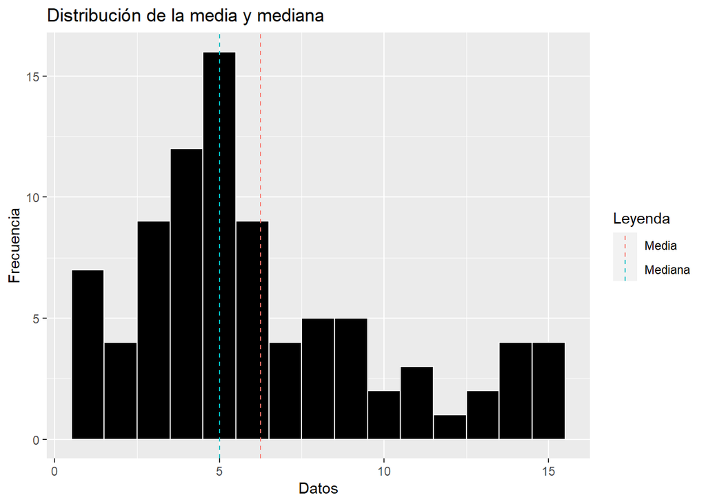

```r
df <- data.frame(z)

ggplot(df, aes(x = z)) +
  geom_histogram(binwidth = 1, fill="black", color="white") +
  geom_vline(aes(xintercept = mean(z), color = "Media"), linetype = "dashed") +
  geom_vline(aes(xintercept = median(z), color = "Mediana"), linetype = "dashed") +
  labs(title = "Distribución de la media y mediana", x = "Datos", y = "Frecuencia", color = "Leyenda")
```

La desviación estándar nos indica la dispersión de los datos con respecto a la media. Este resultado puede significar que hay una amplia variabilidad en las horas de estudio entre los estudiantes.

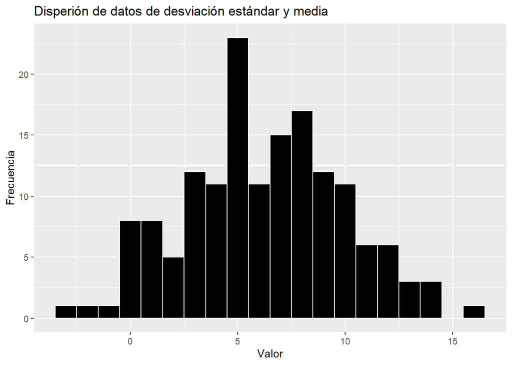

```r
datos <- data.frame(v = rnorm(155, mean = 6.25, sd = 3.84))

ggplot(datos, aes(x = v)) +
  geom_histogram(binwidth = 1, color = "white", fill = "black") +
  labs(title = "Disperión de datos de desviación estándar y media",
       x = "Valor", y = "Frecuencia")
```

2. Análisis de la actividad física:

Los resultados de la encuesta se muestra que la mayoría de personas hace deporte, con un porcentaje…

```r
r(prop.table(table(DF$Deporte)) * 100)
```

```
##
##    No    Si
## 43.87 56.13
```

En este gráfico se puede observar que los hombres encuestados realizan mayor cantidad de ejercicio en comparación con las mujeres.

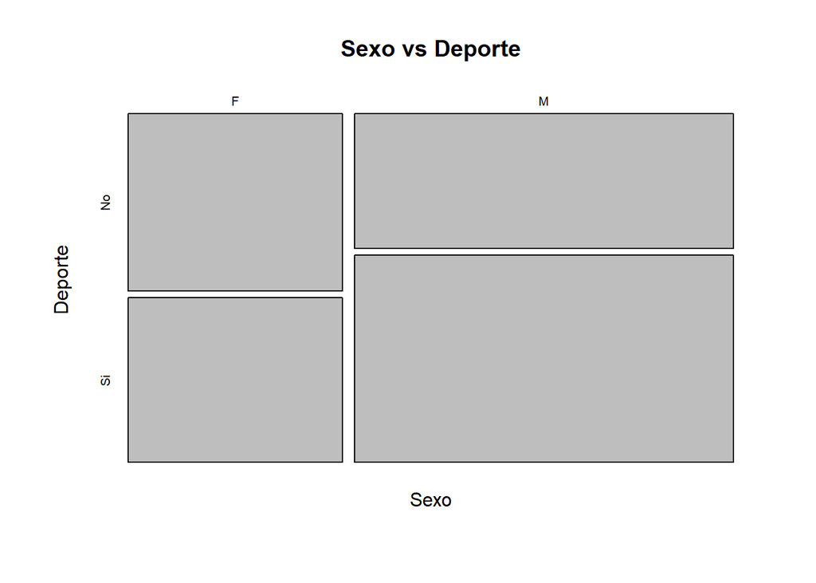

```r
mosaicplot(DF$Sexo ~ DF$Deporte, main = "Sexo vs Deporte", xlab = "Sexo", ylab = "Deporte")
```

La media es 3.2, esto significa que las personas están entrenando alrededor de este resultado obtenido por semana. La mediana es una medida resistente a los valores atípicos y proporciona una idea de la ubicación central de los datos, siendo en este caso 3 horas por semana, indicando el valor central en el conjunto de datos ordenados.

```r
DF %>% summarise(media = r(mean(l)),
            mediana = median(l))
```

| media | mediana |
| --- | --- |
| 3.2 | 3 |

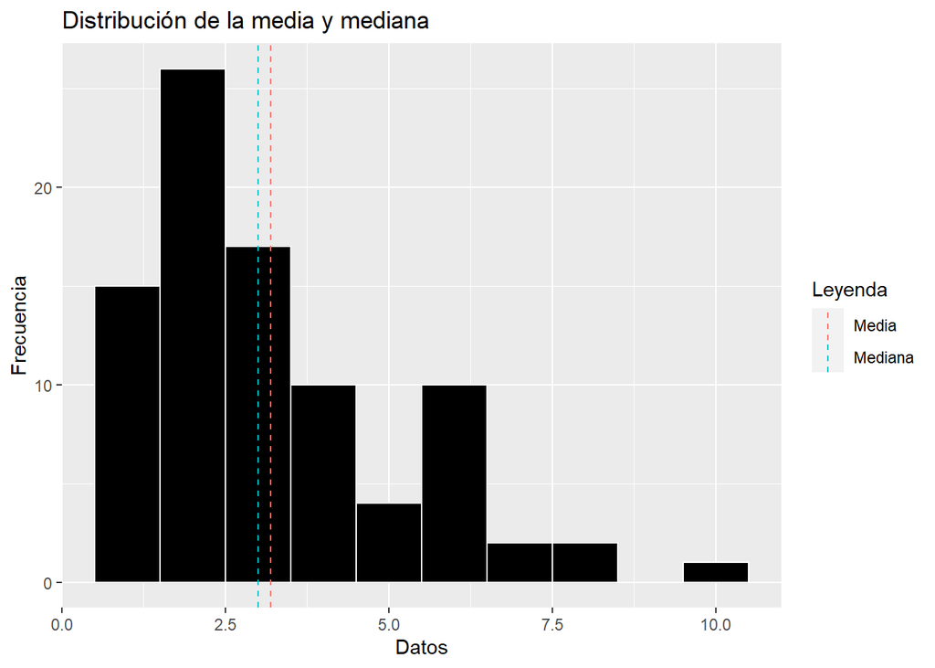

```r
df1 <- data.frame(l)

ggplot(df1, aes(x = l)) +
  geom_histogram(binwidth = 1, fill="black", color="white") +
  geom_vline(aes(xintercept = mean(l), color = "Media"), linetype = "dashed") +
  geom_vline(aes(xintercept = median(l), color = "Mediana"), linetype = "dashed") +
  labs(title = "Distribución de la media y mediana", x = "Datos", y = "Frecuencia", color = "Leyenda")
```

3. Relación entre el tiempo de estudio y la actividad física:

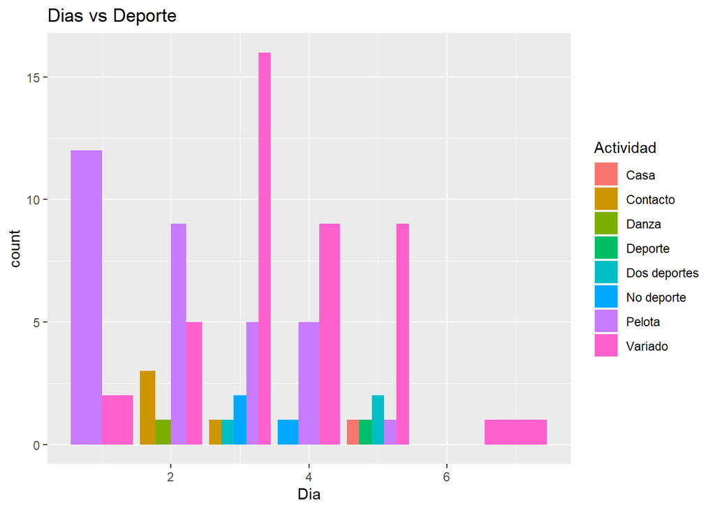

```r
ggplot(DF, aes(x = Dia, fill = Actividad)) + geom_bar(position="dodge") + labs(title = "Dias vs Deporte")
```

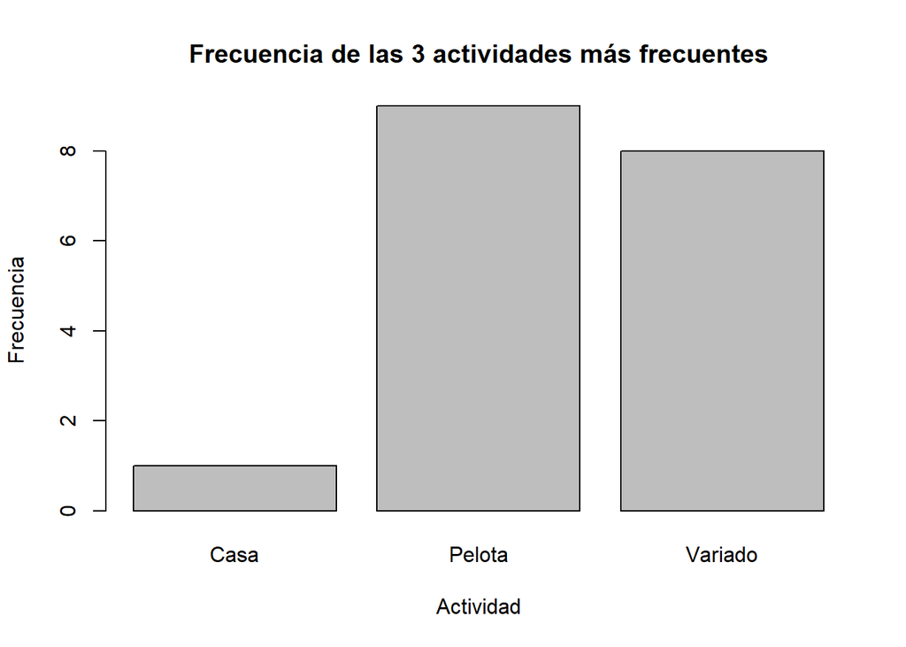

```r
# Convertir la columna al tipo numérico
DF$Promedio <- as.numeric(DF$Promedio)

# Filtrar el tercio superior de la variable "Promedio"
tercio_superior <- quantile(DF$Promedio, probs = 2/3, na.rm = T)

# Filtrar la "Actividad" más frecuente que no sea NA
actividad_frecuente <- names(sort(table(DF$Actividad, useNA = "no"), decreasing = T))[1]

# Crear un nuevo dataframe con las observaciones del tercio superior y la actividad frecuente
nuevo_df <- DF[DF$Promedio >= tercio_superior,]

# Filtrar las observaciones con actividad no NA en nuevo_df
actividades <- na.omit(nuevo_df$Actividad)

# Obtener las tres actividades más frecuentes
actividades_frecuentes <- names(sort(table(actividades), decreasing = TRUE))[1:3]

# Filtrar nuevo_df solo para las tres actividades más frecuentes
nuevo_df_frecuentes <- nuevo_df[nuevo_df$Actividad %in% actividades_frecuentes, ]

# Calcular la frecuencia de las tres actividades más frecuentes
frecuencia_actividades <- table(nuevo_df_frecuentes$Actividad)

# Crear la gráfica de barras
barplot(frecuencia_actividades, main = "Frecuencia de las 3 actividades más frecuentes",
        xlab = "Actividad", ylab = "Frecuencia")
```

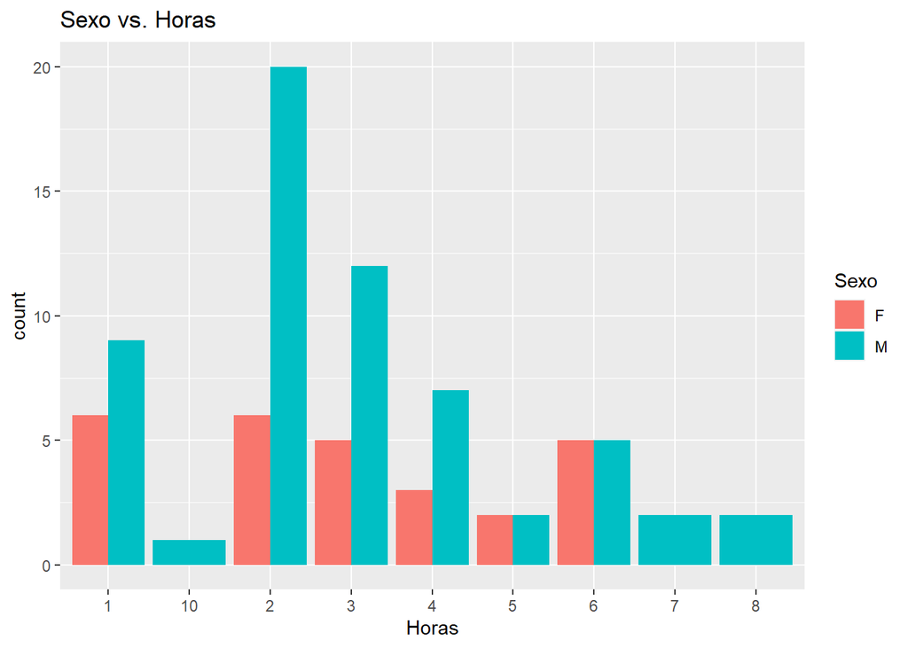

```r
# Filtrar los valores NA en la variable "Horas" del dataframe DF_clean
DF_clean_horas <- DF[complete.cases(DF$Horas), ]

# Gráfico de barras: Sexo vs. Horas (sin valores NA en Horas)
ggplot(DF_clean_horas, aes(x = Horas, fill = Sexo)) +
  geom_bar(position = "dodge") +
  labs(title = "Sexo vs. Horas")
```

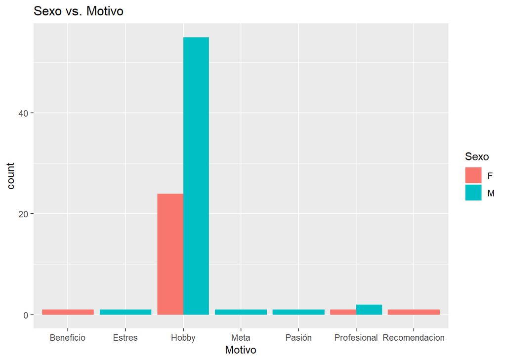

```r
# Filtrar los valores NA en la variable "Motivo" del dataframe DF_clean
DF_clean_motivo <- DF[complete.cases(DF$Motivo), ]

# Gráfico de barras: Sexo vs. Motivo (sin valores NA en Motivo)
ggplot(DF_clean_motivo, aes(x = Motivo, fill = Sexo)) +
  geom_bar(position = "dodge") +
  labs(title = "Sexo vs. Motivo")
```